**Problem Statement**

> Medical research university X is undergoing a deep research on patients with certain conditions. University has an internal AI team. Due to confidentiality the patient’s details and the conditions are masked by the client by providing different datasets to the AI team for developing a AIML model which can predict the condition of the patient depending on the received test results.

# **Import Libraries**

```python
# Pandas is used for data manipulation and analysis
import pandas as pd
# Numpy is used for large, multi-dimensional arrays and matrices, along with mathematical operators on these arrays
import numpy as np
# Matplotlib is a data visualization library for 2D plots of arrays, built on NumPy arrays
# and designed to work with the broader SciPy stack
import matplotlib.pyplot as plt
from sklearn.metrics import f1_score
%matplotlib inline
import seaborn as sns
```

# **Read Data**

*1. Data Understanding:*

**A. Read all the 3 CSV files as DataFrame and store them into 3 separate variables.**

```python
# Mount the google drive. this is additional configuration needed if we use google colabs
from google.colab import drive
drive.mount('/content/drive')
import os
os.chdir('/content/drive/My Drive/Colab Notebooks/Projects/Supervised-Learning')
```

```python
df1 = pd.read_csv("Part1_Normal.csv")
df2 = pd.read_csv("Part1_Type_H.csv")
df3 = pd.read_csv("Part1_Type_S.csv")
```

**B. Print Shape and columns of all the 3 DataFrames.**

```python
def show_shape_and_columns(df):
  _shape = df.shape
  _columns = df.columns
  return _shape, _columns

s1, c1 = show_shape_and_columns(df1)
print(f"Shape of Normal data set {s1} and columns are  {c1.to_list()}")
print("\n")
s2, c2 = show_shape_and_columns(df2)
print(f"Shape of Type H data set {s2}  and columns are  {c2.to_list()}")
print("\n")
s3, c3 = show_shape_and_columns(df3)
print(f"Shape of Type S data set {s3} and columns are  {c3.to_list()}")
```

```
Shape of Normal data set (100, 7) and columns are  ['P_incidence', 'P_tilt', 'L_angle', 'S_slope', 'P_radius', 'S_Degree', 'Class']


Shape of Type H data set (60, 7)  and columns are  ['P_incidence', 'P_tilt', 'L_angle', 'S_slope', 'P_radius', 'S_Degree', 'Class']


Shape of Type S data set (150, 7) and columns are  ['P_incidence', 'P_tilt', 'L_angle', 'S_slope', 'P_radius', 'S_Degree', 'Class']
```

**C. Compare Column names of all the 3 DataFrames and clearly write observations.**

```python
compare = [True if i == j == k else False for i,j,k in zip(c1, c2, c3)]
if all(compare):
  print("All Colums are same")
else:
  print("All columns are not same")
```

```
All Colums are same
```

**D. Print DataTypes of all the 3 DataFrames.**

```python
print("Data types of Normal data set")
df1.info()
```

```
Data types of Normal data set
<class 'pandas.core.frame.DataFrame'>
RangeIndex: 100 entries, 0 to 99
Data columns (total 7 columns):
 #   Column       Non-Null Count  Dtype
---  ------       --------------  -----
 0   P_incidence  100 non-null    float64
 1   P_tilt       100 non-null    float64
 2   L_angle      100 non-null    float64
 3   S_slope      100 non-null    float64
 4   P_radius     100 non-null    float64
 5   S_Degree     100 non-null    float64
 6   Class        100 non-null    object
dtypes: float64(6), object(1)
memory usage: 5.6+ KB
```

```python
print("Data types of Type H data set")
df2.info()
```

```
Data types of Type H data set
<class 'pandas.core.frame.DataFrame'>
RangeIndex: 60 entries, 0 to 59
Data columns (total 7 columns):
 #   Column       Non-Null Count  Dtype
---  ------       --------------  -----
 0   P_incidence  60 non-null     float64
 1   P_tilt       60 non-null     float64
 2   L_angle      60 non-null     float64
 3   S_slope      60 non-null     float64
 4   P_radius     60 non-null     float64
 5   S_Degree     60 non-null     float64
 6   Class        60 non-null     object
dtypes: float64(6), object(1)
memory usage: 3.4+ KB
```

```python
print("Data types of Type S data set")
df3.info()
```

```
Data types of Type S data set
<class 'pandas.core.frame.DataFrame'>
RangeIndex: 150 entries, 0 to 149
Data columns (total 7 columns):
 #   Column       Non-Null Count  Dtype
---  ------       --------------  -----
 0   P_incidence  150 non-null    float64
 1   P_tilt       150 non-null    float64
 2   L_angle      150 non-null    float64
 3   S_slope      150 non-null    float64
 4   P_radius     150 non-null    float64
 5   S_Degree     150 non-null    float64
 6   Class        150 non-null    object
dtypes: float64(6), object(1)
memory usage: 8.3+ KB
```

**E. Observe and share variation in ‘Class’ feature of all the 3 DaraFrames.**

```python
print(f"Variation is Normal type class feature - {set(df1.Class.to_list())}")
print(f"Variation is H type class feature - {set(df2.Class.to_list())}")
print(f"Variation is S type class feature - {set(df3.Class.to_list())}")
```

```
Variation is Normal type class feature - {'Nrmal', 'Normal'}
Variation is H type class feature - {'type_h', 'Type_H'}
Variation is S type class feature - {'Type_S', 'tp_s'}
```

*2. Data Preparation and Exploration:*

**A. Unify all the variations in ‘Class’ feature for all the 3 DataFrames.**

```python
df1["Class"].replace(['Normal', 'Nrmal'], 'normal', inplace=True)
df2["Class"].replace(['Type_H'], 'type_h', inplace=True)
df3["Class"].replace(['Type_S', 'tp_s'], 'type_s', inplace=True)
```

```python
df1.head(10)
```

|  | P_incidence | P_tilt | L_angle | S_slope | P_radius | S_Degree | Class |
| --- | --- | --- | --- | --- | --- | --- | --- |
| 0 | 38.505273 | 16.964297 | 35.112814 | 21.540976 | 127.632875 | 7.986683 | normal |
| 1 | 54.920858 | 18.968430 | 51.601455 | 35.952428 | 125.846646 | 2.001642 | normal |
| 2 | 44.362490 | 8.945435 | 46.902096 | 35.417055 | 129.220682 | 4.994195 | normal |
| 3 | 48.318931 | 17.452121 | 48.000000 | 30.866809 | 128.980308 | -0.910941 | normal |
| 4 | 45.701789 | 10.659859 | 42.577846 | 35.041929 | 130.178314 | -3.388910 | normal |
| 5 | 30.741938 | 13.354966 | 35.903526 | 17.386972 | 142.410107 | -2.005373 | normal |
| 6 | 50.913101 | 6.677000 | 30.896522 | 44.236102 | 118.151531 | -1.057986 | normal |
| 7 | 38.126589 | 6.557617 | 50.445075 | 31.568971 | 132.114805 | 6.338199 | normal |
| 8 | 51.624672 | 15.969344 | 35.000000 | 35.655328 | 129.385308 | 1.009228 | normal |
| 9 | 64.311867 | 26.328369 | 50.958964 | 37.983498 | 106.177751 | 3.118221 | normal |

```python
df2.head(10)
```

|  | P_incidence | P_tilt | L_angle | S_slope | P_radius | S_Degree | Class |
| --- | --- | --- | --- | --- | --- | --- | --- |
| 0 | 63.027817 | 22.552586 | 39.609117 | 40.475232 | 98.672917 | -0.254400 | type_h |
| 1 | 39.056951 | 10.060991 | 25.015378 | 28.995960 | 114.405425 | 4.564259 | type_h |
| 2 | 68.832021 | 22.218482 | 50.092194 | 46.613539 | 105.985135 | -3.530317 | type_h |
| 3 | 69.297008 | 24.652878 | 44.311238 | 44.644130 | 101.868495 | 11.211523 | type_h |
| 4 | 49.712859 | 9.652075 | 28.317406 | 40.060784 | 108.168725 | 7.918501 | type_h |
| 5 | 40.250200 | 13.921907 | 25.124950 | 26.328293 | 130.327871 | 2.230652 | type_h |
| 6 | 53.432928 | 15.864336 | 37.165934 | 37.568592 | 120.567523 | 5.988551 | type_h |
| 7 | 45.366754 | 10.755611 | 29.038349 | 34.611142 | 117.270067 | -10.675871 | type_h |
| 8 | 43.790190 | 13.533753 | 42.690814 | 30.256437 | 125.002893 | 13.289018 | type_h |
| 9 | 36.686353 | 5.010884 | 41.948751 | 31.675469 | 84.241415 | 0.664437 | type_h |

```python
df3.head(10)
```

|  | P_incidence | P_tilt | L_angle | S_slope | P_radius | S_Degree | Class |
| --- | --- | --- | --- | --- | --- | --- | --- |
| 0 | 74.377678 | 32.053104 | 78.772013 | 42.324573 | 143.560690 | 56.125906 | type_s |
| 1 | 89.680567 | 32.704435 | 83.130732 | 56.976132 | 129.955476 | 92.027277 | type_s |
| 2 | 44.529051 | 9.433234 | 52.000000 | 35.095817 | 134.711772 | 29.106575 | type_s |
| 3 | 77.690577 | 21.380645 | 64.429442 | 56.309932 | 114.818751 | 26.931841 | type_s |
| 4 | 76.147212 | 21.936186 | 82.961502 | 54.211027 | 123.932010 | 10.431972 | type_s |
| 5 | 83.933009 | 41.286305 | 62.000000 | 42.646703 | 115.012334 | 26.588100 | type_s |
| 6 | 78.491730 | 22.181798 | 60.000000 | 56.309932 | 118.530327 | 27.383213 | type_s |
| 7 | 75.649731 | 19.339799 | 64.148685 | 56.309932 | 95.903629 | 69.551303 | type_s |
| 8 | 72.076278 | 18.946176 | 51.000000 | 53.130102 | 114.213013 | 1.010041 | type_s |
| 9 | 58.599529 | -0.261499 | 51.500000 | 58.861028 | 102.042812 | 28.059697 | type_s |

**B. Combine all the 3 DataFrames to form a single DataFrame**

```python
frames = [df1, df2, df3]
final_df = pd.concat(frames, ignore_index=True)
final_df
```

|  | P_incidence | P_tilt | L_angle | S_slope | P_radius | S_Degree | Class |
| --- | --- | --- | --- | --- | --- | --- | --- |
| 0 | 38.505273 | 16.964297 | 35.112814 | 21.540976 | 127.632875 | 7.986683 | normal |
| 1 | 54.920858 | 18.968430 | 51.601455 | 35.952428 | 125.846646 | 2.001642 | normal |
| 2 | 44.362490 | 8.945435 | 46.902096 | 35.417055 | 129.220682 | 4.994195 | normal |
| 3 | 48.318931 | 17.452121 | 48.000000 | 30.866809 | 128.980308 | -0.910941 | normal |
| 4 | 45.701789 | 10.659859 | 42.577846 | 35.041929 | 130.178314 | -3.388910 | normal |
| ... | ... | ... | ... | ... | ... | ... | ... |
| 305 | 80.111572 | 33.942432 | 85.101608 | 46.169139 | 125.593624 | 100.292107 | type_s |
| 306 | 95.480229 | 46.550053 | 59.000000 | 48.930176 | 96.683903 | 77.283072 | type_s |
| 307 | 74.094731 | 18.823727 | 76.032156 | 55.271004 | 128.405731 | 73.388216 | type_s |
| 308 | 87.679087 | 20.365613 | 93.822416 | 67.313473 | 120.944829 | 76.730629 | type_s |
| 309 | 48.259920 | 16.417462 | 36.329137 | 31.842457 | 94.882336 | 28.343799 | type_s |

310 rows × 7 columns

**C. Print 5 random samples of this DataFrame**

```python
final_df.sample(n=5)
```

|  | P_incidence | P_tilt | L_angle | S_slope | P_radius | S_Degree | Class |
| --- | --- | --- | --- | --- | --- | --- | --- |
| 215 | 129.834041 | 8.404475 | 48.384057 | 121.429566 | 107.690466 | 418.543082 | type_s |
| 216 | 70.484104 | 12.489488 | 62.417142 | 57.994617 | 114.190049 | 56.902448 | type_s |
| 106 | 53.432928 | 15.864336 | 37.165934 | 37.568592 | 120.567523 | 5.988551 | type_h |
| 185 | 45.443750 | 9.906072 | 45.000000 | 35.537678 | 163.071041 | 20.315315 | type_s |
| 37 | 49.828135 | 16.736435 | 28.000000 | 33.091700 | 121.435558 | 1.913307 | normal |

**D. Print Feature-wise percentage of Null values.**

```python
final_df.isnull().sum()
```

```
P_incidence    0
P_tilt         0
L_angle        0
S_slope        0
P_radius       0
S_Degree       0
Class          0
dtype: int64
```

```python
percent_missing = final_df.isnull().sum() * 100 / len(final_df)
missing_value_df = pd.DataFrame({'column_name': final_df.columns,
                                 'percent_missing': percent_missing})
missing_value_df
```

|  | column_name | percent_missing |
| --- | --- | --- |
| P_incidence | P_incidence | 0.0 |
| P_tilt | P_tilt | 0.0 |
| L_angle | L_angle | 0.0 |
| S_slope | S_slope | 0.0 |
| P_radius | P_radius | 0.0 |
| S_Degree | S_Degree | 0.0 |
| Class | Class | 0.0 |

**E. Check 5-point summary of the new DataFrame.**

```python
final_df.describe().T
```

|  | count | mean | std | min | 25% | 50% | 75% | max |
| --- | --- | --- | --- | --- | --- | --- | --- | --- |
| P_incidence | 310.0 | 60.496653 | 17.236520 | 26.147921 | 46.430294 | 58.691038 | 72.877696 | 129.834041 |
| P_tilt | 310.0 | 17.542822 | 10.008330 | -6.554948 | 10.667069 | 16.357689 | 22.120395 | 49.431864 |
| L_angle | 310.0 | 51.930930 | 18.554064 | 14.000000 | 37.000000 | 49.562398 | 63.000000 | 125.742385 |
| S_slope | 310.0 | 42.953831 | 13.423102 | 13.366931 | 33.347122 | 42.404912 | 52.695888 | 121.429566 |
| P_radius | 310.0 | 117.920655 | 13.317377 | 70.082575 | 110.709196 | 118.268178 | 125.467674 | 163.071041 |
| S_Degree | 310.0 | 26.296694 | 37.559027 | -11.058179 | 1.603727 | 11.767934 | 41.287352 | 418.543082 |

*3. Data Analysis:*

**Visualize a heatmap to understand correlation between all features**

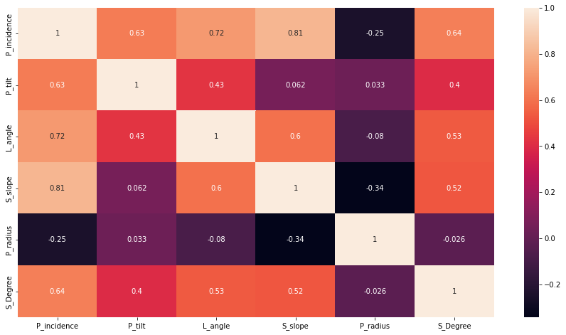

```python
plt.figure(figsize=(15,8))
sns.heatmap(final_df.corr(), annot = True)
```

**B. Share insights on correlation.**

```python
final_df.corr()
```

|  | P_incidence | P_tilt | L_angle | S_slope | P_radius | S_Degree |
| --- | --- | --- | --- | --- | --- | --- |
| P_incidence | 1.000000 | 0.629199 | 0.717282 | 0.814960 | -0.247467 | 0.638743 |
| P_tilt | 0.629199 | 1.000000 | 0.432764 | 0.062345 | 0.032668 | 0.397862 |
| L_angle | 0.717282 | 0.432764 | 1.000000 | 0.598387 | -0.080344 | 0.533667 |
| S_slope | 0.814960 | 0.062345 | 0.598387 | 1.000000 | -0.342128 | 0.523557 |
| P_radius | -0.247467 | 0.032668 | -0.080344 | -0.342128 | 1.000000 | -0.026065 |
| S_Degree | 0.638743 | 0.397862 | 0.533667 | 0.523557 | -0.026065 | 1.000000 |

*A. Features having stronger correlation with correlation value.*

```python
def get_redundant_pairs(df):
    '''Get diagonal and lower triangular pairs of correlation matrix'''
    df = df.drop(["Class"], axis='columns')
    pairs_to_drop = set()
    cols = df.columns
    for i in range(0, df.shape[1]):
        for j in range(0, i+1):
            pairs_to_drop.add((cols[i], cols[j]))
    return pairs_to_drop

def get_top_abs_correlations(df, n=5):
    au_corr = df.corr().abs().unstack()
    labels_to_drop = get_redundant_pairs(df)
    top_corr = au_corr.drop(labels=labels_to_drop).sort_values(ascending=False)
    week_corr = au_corr.drop(labels=labels_to_drop).sort_values(ascending=True)
    return top_corr[0:n], week_corr[0:n]

print("Top 3 stronger absolute Correlations")
print(get_top_abs_correlations(final_df, 3)[0])
```

```
Top 3 stronger absolute Correlations
P_incidence  S_slope     0.814960
             L_angle     0.717282
             S_Degree    0.638743
dtype: float64
```

*B. Features having weaker correlation with correlation value.*

```python
print("Top 2 weeker absolute Correlations")
print(get_top_abs_correlations(final_df, 2)[1])
```

```
Top 2 weeker absolute Correlations
P_radius  S_Degree    0.026065
P_tilt    P_radius    0.032668
dtype: float64
```

**C. Visualize a pairplot with 3 classes distinguished by colors and share insights**

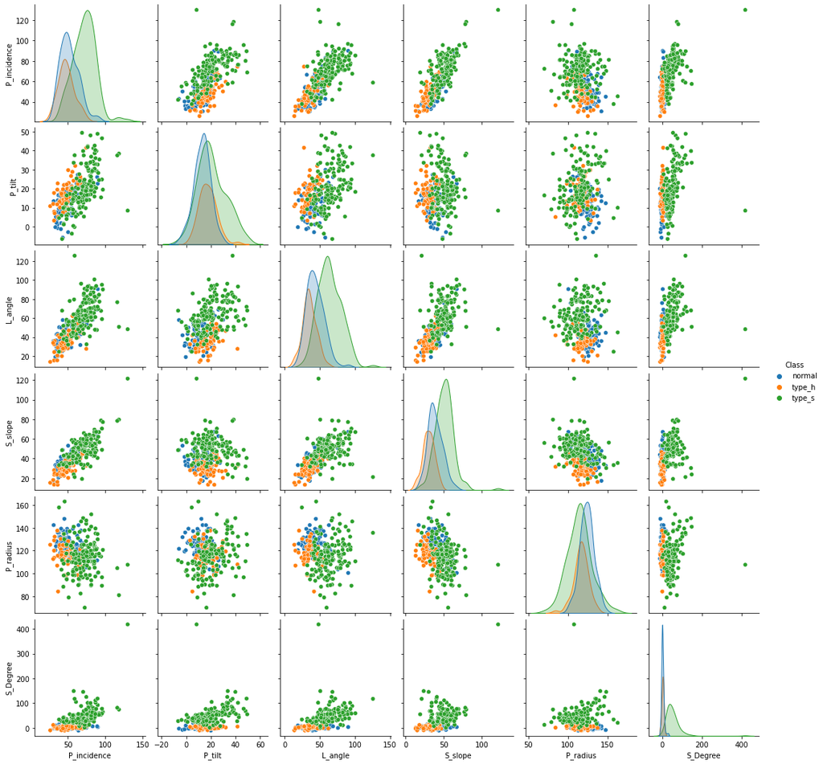

```python
sns.pairplot(final_df, hue = "Class")
```

In the above plot scatter diagrams are plotted for all the numerical columns in the dataset. A scatter plot is a visual representation of the degree of correlation between any two columns. The pair plot function in seaborn makes it very easy to generate joint scatter plots for all the columns in the data.

From the above plot we can infer that

> feature pair (P_incidence, S_slope), (P_incidence, L_angle) , (P_incidence, S_Degree), (S_slope, L_angle) are hinghly correlated. And feature pair like (P_radius, S_Degree), (P_tilt, P_radius) are weekly correlated.

**D. Visualize a jointplot for ‘P_incidence’ and ‘S_slope’ and share insights**

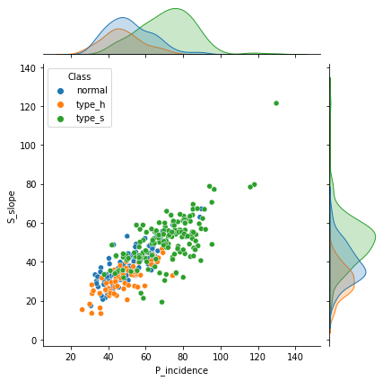

```python
sns.jointplot(data=final_df, x="P_incidence", y="S_slope", hue = "Class")
```

From above graph, we can clearly observe that P_incidence and S_slope are higly correlated. Also type_h having lower P_incidence and type_s having higher P_incidence while normal types are distributed in between type_h and type_s.

**E. Visualize a boxplot to check distribution of the features and share insights.**

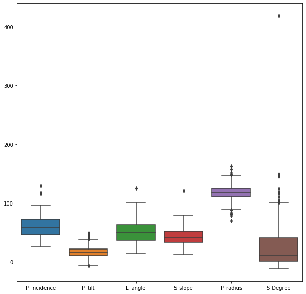

```python
plt.figure(figsize=(10, 10))
sns.boxplot(data=final_df)
```

1. From above boxplot, we can infer that almost all feature have outliears.
2. S_Degree have maximum outliars
3. P_radiuus have higher values
4. P_tilt have lower values
5. S_Degree is having skewed distribution
6. All other features have almost symmetric distribution

*4. Model Building*

**A. Split data into X and Y**

```python
import numpy as np
# Transform data into features and target
#Create x and y variables.
x = final_df.drop(columns=['Class'])
y = final_df['Class']
```

**B. Split data into train and test with 80:20 proportion.**

```python
# split into train and test
from sklearn.model_selection import train_test_split
x_train, x_test, y_train, y_test = train_test_split(x, y, test_size=0.2, random_state=7)
```

```python
print(x_train.shape)
print(y_train.shape)
```

```
(248, 6)
(248,)
```

```python
print(x_test.shape)
print(y_test.shape)
```

```
(62, 6)
(62,)
```

**Preprocessing**

```python
from sklearn.preprocessing import StandardScaler
mm = StandardScaler()

x_train = mm.fit_transform(x_train)
x_test = mm.transform(x_test)
```

**C. Train a Supervised Learning Classification base model using KNN classifier**

```python
# loading library
from sklearn.neighbors import KNeighborsClassifier
from sklearn.metrics import accuracy_score
from sklearn.metrics import recall_score
from sklearn.metrics import precision_score

# instantiate learning model (k = 3)
knn = KNeighborsClassifier(n_neighbors = 3)

# fitting the model
knn.fit(x_train, y_train)

# predict the response
y_pred = knn.predict(x_test)
```

```python
# evaluate accuracy
print("Accuracy Score", accuracy_score(y_test, y_pred))
```

```
Accuracy Score 0.7903225806451613
```

```python
print("Recall Score", recall_score(y_test, y_pred, average='micro'))
```

```
Recall Score 0.7903225806451613
```

```python
print("Precision Score", precision_score(y_test, y_pred, average='micro'))
```

```
Precision Score 0.7903225806451613
```

```python
from sklearn.metrics import confusion_matrix
matrix = confusion_matrix(y_test, y_pred)
matrix
```

```
array([[17,  1,  3],
       [ 5,  8,  1],
       [ 2,  1, 24]])
```

```python
from sklearn.metrics import classification_report
report = classification_report(y_test, y_pred)
print(report)
```

```
              precision    recall  f1-score   support

      normal       0.71      0.81      0.76        21
      type_h       0.80      0.57      0.67        14
      type_s       0.86      0.89      0.87        27

    accuracy                           0.79        62
   macro avg       0.79      0.76      0.76        62
weighted avg       0.79      0.79      0.79        62
```

*5. Performance Improvement:*

**A. Experiment with various parameters to improve performance of the base model.**

```python
# instantiate learning model (k = 3)
knn = KNeighborsClassifier(n_neighbors = 3)

# fitting the model
knn.fit(x_train, y_train)

# predict the response
y_pred = knn.predict(x_test)

# evaluate accuracy
print("Accuracy k= 3",accuracy_score(y_test, y_pred))

# instantiate learning model (k = 5)
knn = KNeighborsClassifier(n_neighbors=5)

# fitting the model
knn.fit(x_train, y_train)

# predict the response
y_pred = knn.predict(x_test)

# evaluate accuracy
print("Accuracy k= 5", accuracy_score(y_test, y_pred))

# instantiate learning model (k = 9)
knn = KNeighborsClassifier(n_neighbors=9)

# fitting the model
knn.fit(x_train, y_train)

# predict the response
y_pred = knn.predict(x_test)

# evaluate accuracy
print("Accuracy k= 9", accuracy_score(y_test, y_pred))

print("Clearly we are getting highest accuracy with k = 3")
```

```
Accuracy k= 3 0.7903225806451613
Accuracy k= 5 0.7903225806451613
Accuracy k= 9 0.7741935483870968
Clearly we are getting highest accuracy with k = 3
```

```python
# creating odd list of K for KNN
myList = list(range(1,20, 2))
```

```python
# empty list that will hold accuracy scores
ac_scores = []

# perform accuracy metrics for values from 1,3,5....19
for k in myList:
    knn = KNeighborsClassifier(n_neighbors=k)
    knn.fit(x_train, y_train)
    # predict the response
    y_pred = knn.predict(x_test)
    # evaluate accuracy
    scores = accuracy_score(y_test, y_pred)
    ac_scores.append(scores)

# changing to misclassification error
MSE = [1 - x for x in ac_scores]

# determining best k
optimal_k = myList[MSE.index(min(MSE))]
print(f"The optimal number of neighbors is {optimal_k}")
```

```
The optimal number of neighbors is 11
```

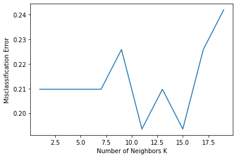

```python
import matplotlib.pyplot as plt
# plot misclassification error vs k
plt.plot(myList, MSE)
plt.xlabel('Number of Neighbors K')
plt.ylabel('Misclassification Error')
plt.show()
```

B. Clearly showcase improvement in performance **achieved**

```python
#Use k=11 as the final model for prediction
knn = KNeighborsClassifier(n_neighbors = 11, p = 2)

# fitting the model
knn.fit(x_train, y_train)

# predict the response
y_pred = knn.predict(x_test)

# evaluate accuracy
print("Accuracy", accuracy_score(y_test, y_pred))
print("Recall", recall_score(y_test, y_pred, average='micro'))
print("Precision", precision_score(y_test, y_pred, average='micro'))
```

```
Accuracy 0.8064516129032258
Recall 0.8064516129032258
Precision 0.8064516129032258
```

Now, we can clearly say that there is +1% change in Accuracy and Precision

```python
# calculating the accuracy of models with different values of k
from sklearn import metrics
mean_acc = np.zeros(20)
for i in range(1,21):
    #Train Model and Predict
    knn = KNeighborsClassifier(n_neighbors = i).fit(x_train,y_train)
    yhat= knn.predict(x_test)
    mean_acc[i-1] = metrics.accuracy_score(y_test, yhat)

print(mean_acc)
```

```
[0.79032258 0.79032258 0.79032258 0.79032258 0.79032258 0.77419355
 0.79032258 0.79032258 0.77419355 0.80645161 0.80645161 0.77419355
 0.79032258 0.77419355 0.80645161 0.77419355 0.77419355 0.77419355
 0.75806452 0.74193548]
```

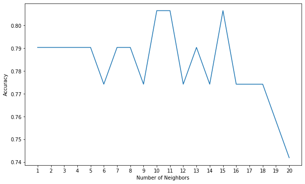

```python
loc = np.arange(1,21,step=1.0)
plt.figure(figsize = (10, 6))
plt.plot(range(1,21), mean_acc)
plt.xticks(loc)
plt.xlabel('Number of Neighbors ')
plt.ylabel('Accuracy')
plt.show()
```

```python
from sklearn.model_selection import cross_val_score
scores = cross_val_score(knn, x, y, cv =5)
```

```python
print('Model accuracy: ',np.mean(scores))
```

```
Model accuracy:  0.8451612903225806
```

**Clearly state which parameters contributed most to improve model performance.**

*Now, from above calcualtions we can clearly say that value of k contributed most to improve model performance*

# **Part B**

*A bank X is on a massive digital transformation for all its departments. Bank has a growing customer base whee majority of them are liability customers (depositors) vs borrowers (asset customers). The bank is interested in expanding the borrowers base rapidly to bring in more business via loan interests. A campaign that the bank ran in last quarter showed an average single digit conversion rate. Digital transformation being the core strength of the business strategy, marketing department wants to devise effective campaigns with better target marketing to increase the conversion ratio to double digit with same budget as per last campaign.*

# **1. Data Understanding and Preparation:**

**A. Read both the Datasets ‘Data1’ and ‘Data 2’ as DataFrame and store them into two separate variables.**

```python
cust_data1 = pd.read_csv("Data1.csv")
cust_data2 = pd.read_csv("Data2.csv")
```

```python
cust_data1.head(20)
```

|  | ID | Age | CustomerSince | HighestSpend | ZipCode | HiddenScore | MonthlyAverageSpend | Level |
| --- | --- | --- | --- | --- | --- | --- | --- | --- |
| 0 | 1 | 25 | 1 | 49 | 91107 | 4 | 1.6 | 1 |
| 1 | 2 | 45 | 19 | 34 | 90089 | 3 | 1.5 | 1 |
| 2 | 3 | 39 | 15 | 11 | 94720 | 1 | 1.0 | 1 |
| 3 | 4 | 35 | 9 | 100 | 94112 | 1 | 2.7 | 2 |
| 4 | 5 | 35 | 8 | 45 | 91330 | 4 | 1.0 | 2 |
| 5 | 6 | 37 | 13 | 29 | 92121 | 4 | 0.4 | 2 |
| 6 | 7 | 53 | 27 | 72 | 91711 | 2 | 1.5 | 2 |
| 7 | 8 | 50 | 24 | 22 | 93943 | 1 | 0.3 | 3 |
| 8 | 9 | 35 | 10 | 81 | 90089 | 3 | 0.6 | 2 |
| 9 | 10 | 34 | 9 | 180 | 93023 | 1 | 8.9 | 3 |
| 10 | 11 | 65 | 39 | 105 | 94710 | 4 | 2.4 | 3 |
| 11 | 12 | 29 | 5 | 45 | 90277 | 3 | 0.1 | 2 |
| 12 | 13 | 48 | 23 | 114 | 93106 | 2 | 3.8 | 3 |
| 13 | 14 | 59 | 32 | 40 | 94920 | 4 | 2.5 | 2 |
| 14 | 15 | 67 | 41 | 112 | 91741 | 1 | 2.0 | 1 |
| 15 | 16 | 60 | 30 | 22 | 95054 | 1 | 1.5 | 3 |
| 16 | 17 | 38 | 14 | 130 | 95010 | 4 | 4.7 | 3 |
| 17 | 18 | 42 | 18 | 81 | 94305 | 4 | 2.4 | 1 |
| 18 | 19 | 46 | 21 | 193 | 91604 | 2 | 8.1 | 3 |
| 19 | 20 | 55 | 28 | 21 | 94720 | 1 | 0.5 | 2 |

```python
cust_data2.head(20)
```

|  | ID | Mortgage | Security | FixedDepositAccount | InternetBanking | CreditCard | LoanOnCard |
| --- | --- | --- | --- | --- | --- | --- | --- |
| 0 | 1 | 0 | 1 | 0 | 0 | 0 | NaN |
| 1 | 2 | 0 | 1 | 0 | 0 | 0 | NaN |
| 2 | 3 | 0 | 0 | 0 | 0 | 0 | NaN |
| 3 | 4 | 0 | 0 | 0 | 0 | 0 | NaN |
| 4 | 5 | 0 | 0 | 0 | 0 | 1 | NaN |
| 5 | 6 | 155 | 0 | 0 | 1 | 0 | NaN |
| 6 | 7 | 0 | 0 | 0 | 1 | 0 | NaN |
| 7 | 8 | 0 | 0 | 0 | 0 | 1 | NaN |
| 8 | 9 | 104 | 0 | 0 | 1 | 0 | NaN |
| 9 | 10 | 0 | 0 | 0 | 0 | 0 | 1.0 |
| 10 | 11 | 0 | 0 | 0 | 0 | 0 | 0.0 |
| 11 | 12 | 0 | 0 | 0 | 1 | 0 | 0.0 |
| 12 | 13 | 0 | 1 | 0 | 0 | 0 | 0.0 |
| 13 | 14 | 0 | 0 | 0 | 1 | 0 | 0.0 |
| 14 | 15 | 0 | 1 | 0 | 0 | 0 | 0.0 |
| 15 | 16 | 0 | 0 | 0 | 1 | 1 | 0.0 |
| 16 | 17 | 134 | 0 | 0 | 0 | 0 | 1.0 |
| 17 | 18 | 0 | 0 | 0 | 0 | 0 | 0.0 |
| 18 | 19 | 0 | 0 | 0 | 0 | 0 | 1.0 |
| 19 | 20 | 0 | 1 | 0 | 0 | 1 | 0.0 |

**B. Print shape and Column Names and DataTypes of both the Dataframes**

```python
cust_data1.shape
```

```
(5000, 8)
```

```python
cust_data2.shape
```

```
(5000, 7)
```

**C. Merge both the Dataframes on ‘ID’ feature to form a single DataFrame**

```python
result_df = pd.merge(cust_data1, cust_data2, on="ID")
result_df
```

|  | ID | Age | CustomerSince | HighestSpend | ZipCode | HiddenScore | MonthlyAverageSpend | Level | Mortgage | Security | FixedDepositAccount | InternetBanking | CreditCard | LoanOnCard |
| --- | --- | --- | --- | --- | --- | --- | --- | --- | --- | --- | --- | --- | --- | --- |
| 0 | 1 | 25 | 1 | 49 | 91107 | 4 | 1.6 | 1 | 0 | 1 | 0 | 0 | 0 | NaN |
| 1 | 2 | 45 | 19 | 34 | 90089 | 3 | 1.5 | 1 | 0 | 1 | 0 | 0 | 0 | NaN |
| 2 | 3 | 39 | 15 | 11 | 94720 | 1 | 1.0 | 1 | 0 | 0 | 0 | 0 | 0 | NaN |
| 3 | 4 | 35 | 9 | 100 | 94112 | 1 | 2.7 | 2 | 0 | 0 | 0 | 0 | 0 | NaN |
| 4 | 5 | 35 | 8 | 45 | 91330 | 4 | 1.0 | 2 | 0 | 0 | 0 | 0 | 1 | NaN |
| ... | ... | ... | ... | ... | ... | ... | ... | ... | ... | ... | ... | ... | ... | ... |
| 4995 | 4996 | 29 | 3 | 40 | 92697 | 1 | 1.9 | 3 | 0 | 0 | 0 | 1 | 0 | 0.0 |
| 4996 | 4997 | 30 | 4 | 15 | 92037 | 4 | 0.4 | 1 | 85 | 0 | 0 | 1 | 0 | 0.0 |
| 4997 | 4998 | 63 | 39 | 24 | 93023 | 2 | 0.3 | 3 | 0 | 0 | 0 | 0 | 0 | 0.0 |
| 4998 | 4999 | 65 | 40 | 49 | 90034 | 3 | 0.5 | 2 | 0 | 0 | 0 | 1 | 0 | 0.0 |
| 4999 | 5000 | 28 | 4 | 83 | 92612 | 3 | 0.8 | 1 | 0 | 0 | 0 | 1 | 1 | 0.0 |

5000 rows × 14 columns

```python
result_df.shape
```

```
(5000, 14)
```

```python
result_df.info()
```

```
<class 'pandas.core.frame.DataFrame'>
Int64Index: 5000 entries, 0 to 4999
Data columns (total 14 columns):
 #   Column               Non-Null Count  Dtype
---  ------               --------------  -----
 0   ID                   5000 non-null   int64
 1   Age                  5000 non-null   int64
 2   CustomerSince        5000 non-null   int64
 3   HighestSpend         5000 non-null   int64
 4   ZipCode              5000 non-null   int64
 5   HiddenScore          5000 non-null   int64
 6   MonthlyAverageSpend  5000 non-null   float64
 7   Level                5000 non-null   int64
 8   Mortgage             5000 non-null   int64
 9   Security             5000 non-null   int64
 10  FixedDepositAccount  5000 non-null   int64
 11  InternetBanking      5000 non-null   int64
 12  CreditCard           5000 non-null   int64
 13  LoanOnCard           4980 non-null   float64
dtypes: float64(2), int64(12)
memory usage: 585.9 KB
```

```python
result = result_df.drop('ID', axis =1 ) # dropping this column as it will be 1-1 mapping anyways
result.head()
```

|  | Age | CustomerSince | HighestSpend | ZipCode | HiddenScore | MonthlyAverageSpend | Level | Mortgage | Security | FixedDepositAccount | InternetBanking | CreditCard | LoanOnCard |
| --- | --- | --- | --- | --- | --- | --- | --- | --- | --- | --- | --- | --- | --- |
| 0 | 25 | 1 | 49 | 91107 | 4 | 1.6 | 1 | 0 | 1 | 0 | 0 | 0 | NaN |
| 1 | 45 | 19 | 34 | 90089 | 3 | 1.5 | 1 | 0 | 1 | 0 | 0 | 0 | NaN |
| 2 | 39 | 15 | 11 | 94720 | 1 | 1.0 | 1 | 0 | 0 | 0 | 0 | 0 | NaN |
| 3 | 35 | 9 | 100 | 94112 | 1 | 2.7 | 2 | 0 | 0 | 0 | 0 | 0 | NaN |
| 4 | 35 | 8 | 45 | 91330 | 4 | 1.0 | 2 | 0 | 0 | 0 | 0 | 1 | NaN |

**D. Change Datatype of below features to ‘Object’.</br> ‘CreditCard’, ‘InternetBanking’, ‘FixedDepositAccount’, ‘Security’, ‘Level’, ‘HiddenScore’.**

```python
to_obj = ['CreditCard', 'InternetBanking', 'FixedDepositAccount', 'Security', 'Level', 'HiddenScore']
for col in to_obj:
  result[col] = result[col].astype(object)
```

```python
result.info()
```

```
<class 'pandas.core.frame.DataFrame'>
Int64Index: 5000 entries, 0 to 4999
Data columns (total 13 columns):
 #   Column               Non-Null Count  Dtype
---  ------               --------------  -----
 0   Age                  5000 non-null   int64
 1   CustomerSince        5000 non-null   int64
 2   HighestSpend         5000 non-null   int64
 3   ZipCode              5000 non-null   int64
 4   HiddenScore          5000 non-null   object
 5   MonthlyAverageSpend  5000 non-null   float64
 6   Level                5000 non-null   object
 7   Mortgage             5000 non-null   int64
 8   Security             5000 non-null   object
 9   FixedDepositAccount  5000 non-null   object
 10  InternetBanking      5000 non-null   object
 11  CreditCard           5000 non-null   object
 12  LoanOnCard           4980 non-null   float64
dtypes: float64(2), int64(5), object(6)
memory usage: 546.9+ KB
```

```python
result.describe().T
```

|  | count | mean | std | min | 25% | 50% | 75% | max |
| --- | --- | --- | --- | --- | --- | --- | --- | --- |
| Age | 5000.0 | 45.338400 | 11.463166 | 23.0 | 35.0 | 45.0 | 55.0 | 67.0 |
| CustomerSince | 5000.0 | 20.104600 | 11.467954 | -3.0 | 10.0 | 20.0 | 30.0 | 43.0 |
| HighestSpend | 5000.0 | 73.774200 | 46.033729 | 8.0 | 39.0 | 64.0 | 98.0 | 224.0 |
| ZipCode | 5000.0 | 93152.503000 | 2121.852197 | 9307.0 | 91911.0 | 93437.0 | 94608.0 | 96651.0 |
| MonthlyAverageSpend | 5000.0 | 1.937938 | 1.747659 | 0.0 | 0.7 | 1.5 | 2.5 | 10.0 |
| Mortgage | 5000.0 | 56.498800 | 101.713802 | 0.0 | 0.0 | 0.0 | 101.0 | 635.0 |
| LoanOnCard | 4980.0 | 0.096386 | 0.295149 | 0.0 | 0.0 | 0.0 | 0.0 | 1.0 |

# **2. Data Exploration and Analysis:**

**A. Visualize distribution of Target variable ‘LoanOnCard’ and clearly share insights.**

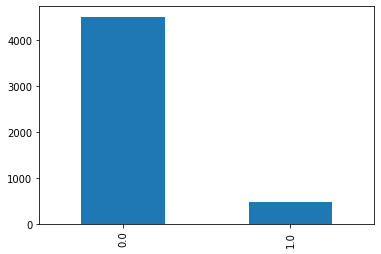

```python
result['LoanOnCard'].value_counts().plot(kind='bar')
```

```python
result['LoanOnCard'].value_counts(normalize=True)
```

```
0.0    0.903614
1.0    0.096386
Name: LoanOnCard, dtype: float64
```

*Around 90% customer don't have loan on card*

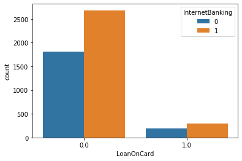

```python
ax = sns.countplot(x="LoanOnCard", hue="InternetBanking", data=result)
```

**B. Check the percentage of missing values and impute if required.**

```python
result.isna().sum()
```

```
Age                     0
CustomerSince           0
HighestSpend            0
ZipCode                 0
HiddenScore             0
MonthlyAverageSpend     0
Level                   0
Mortgage                0
Security                0
FixedDepositAccount     0
InternetBanking         0
CreditCard              0
LoanOnCard             20
dtype: int64
```

```python
percent_missing = result.isnull().sum() * 100 / len(result)
percent_missing
```

```
Age                    0.0
CustomerSince          0.0
HighestSpend           0.0
ZipCode                0.0
HiddenScore            0.0
MonthlyAverageSpend    0.0
Level                  0.0
Mortgage               0.0
Security               0.0
FixedDepositAccount    0.0
InternetBanking        0.0
CreditCard             0.0
LoanOnCard             0.4
dtype: float64
```

*Since missing percentage is very low, we can ignore those records.*

```python
# Droping the data having missing values
result = result.dropna(axis=0)
result
```

|  | Age | CustomerSince | HighestSpend | ZipCode | HiddenScore | MonthlyAverageSpend | Level | Mortgage | Security | FixedDepositAccount | InternetBanking | CreditCard | LoanOnCard |
| --- | --- | --- | --- | --- | --- | --- | --- | --- | --- | --- | --- | --- | --- |
| 9 | 34 | 9 | 180 | 93023 | 1 | 8.9 | 3 | 0 | 0 | 0 | 0 | 0 | 1.0 |
| 10 | 65 | 39 | 105 | 94710 | 4 | 2.4 | 3 | 0 | 0 | 0 | 0 | 0 | 0.0 |
| 11 | 29 | 5 | 45 | 90277 | 3 | 0.1 | 2 | 0 | 0 | 0 | 1 | 0 | 0.0 |
| 12 | 48 | 23 | 114 | 93106 | 2 | 3.8 | 3 | 0 | 1 | 0 | 0 | 0 | 0.0 |
| 13 | 59 | 32 | 40 | 94920 | 4 | 2.5 | 2 | 0 | 0 | 0 | 1 | 0 | 0.0 |
| ... | ... | ... | ... | ... | ... | ... | ... | ... | ... | ... | ... | ... | ... |
| 4995 | 29 | 3 | 40 | 92697 | 1 | 1.9 | 3 | 0 | 0 | 0 | 1 | 0 | 0.0 |
| 4996 | 30 | 4 | 15 | 92037 | 4 | 0.4 | 1 | 85 | 0 | 0 | 1 | 0 | 0.0 |
| 4997 | 63 | 39 | 24 | 93023 | 2 | 0.3 | 3 | 0 | 0 | 0 | 0 | 0 | 0.0 |
| 4998 | 65 | 40 | 49 | 90034 | 3 | 0.5 | 2 | 0 | 0 | 0 | 1 | 0 | 0.0 |
| 4999 | 28 | 4 | 83 | 92612 | 3 | 0.8 | 1 | 0 | 0 | 0 | 1 | 1 | 0.0 |

4980 rows × 13 columns

```python
result.describe().T
```

|  | count | mean | std | min | 25% | 50% | 75% | max |
| --- | --- | --- | --- | --- | --- | --- | --- | --- |
| Age | 4980.0 | 45.352610 | 11.464212 | 23.0 | 35.0 | 45.0 | 55.000 | 67.0 |
| CustomerSince | 4980.0 | 20.117671 | 11.468716 | -3.0 | 10.0 | 20.0 | 30.000 | 43.0 |
| HighestSpend | 4980.0 | 73.852410 | 46.070090 | 8.0 | 39.0 | 64.0 | 98.000 | 224.0 |
| ZipCode | 4980.0 | 93152.420482 | 2123.660073 | 9307.0 | 91911.0 | 93407.0 | 94608.000 | 96651.0 |
| MonthlyAverageSpend | 4980.0 | 1.939536 | 1.750006 | 0.0 | 0.7 | 1.5 | 2.525 | 10.0 |
| Mortgage | 4980.0 | 56.589759 | 101.836758 | 0.0 | 0.0 | 0.0 | 101.000 | 635.0 |
| LoanOnCard | 4980.0 | 0.096386 | 0.295149 | 0.0 | 0.0 | 0.0 | 0.000 | 1.0 |

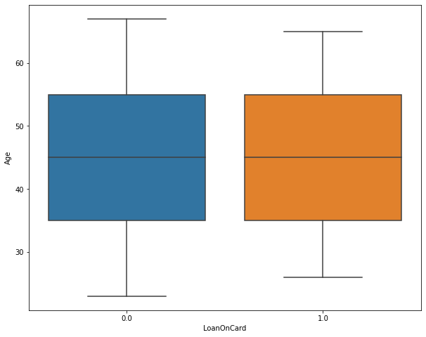

```python
plt.figure(figsize=(10,8))
ax = sns.boxplot(y="Age", x="LoanOnCard", data=result)
```

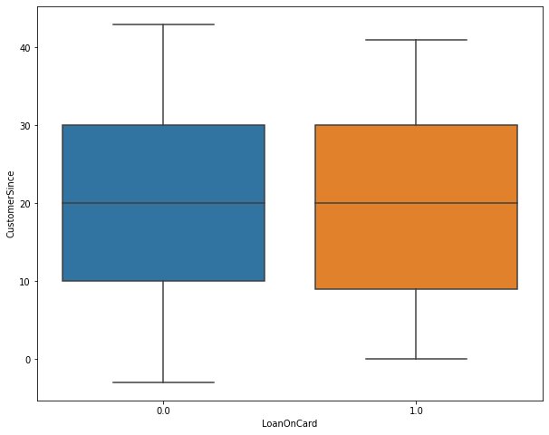

```python
plt.figure(figsize=(10,8))
ax = sns.boxplot(y="CustomerSince", x="LoanOnCard", data=result)
```

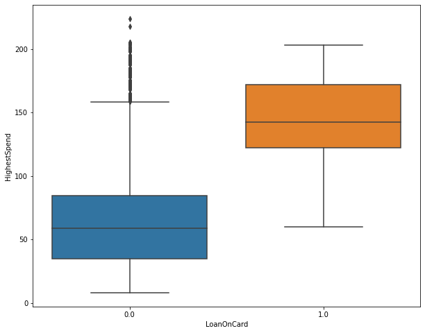

```python
plt.figure(figsize=(10,8))
ax = sns.boxplot(y="HighestSpend", x="LoanOnCard", data=result)
```

*Customers who spend more have highest chances of loan on card.*

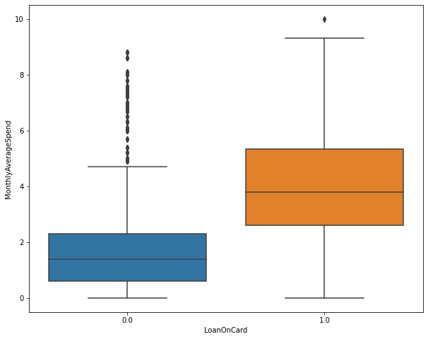

```python
plt.figure(figsize=(10,8))
ax = sns.boxplot(y="MonthlyAverageSpend", x="LoanOnCard", data=result)
```

*Customers who has more monthly average spend, have highest chances of loan on card.*

```python
# Let us look at the target column which is 'LoanOnCard' to understand how the data is distributed amongst the various values
result.groupby(["LoanOnCard"]).mean()
```

| LoanOnCard | Age | CustomerSince | HighestSpend | ZipCode | MonthlyAverageSpend | Mortgage |
| --- | --- | --- | --- | --- | --- | --- |
| 0.0 | 45.383111 | 20.146889 | 66.290444 | 93152.337111 | 1.729849 | 51.869111 |
| 1.0 | 45.066667 | 19.843750 | 144.745833 | 93153.202083 | 3.905354 | 100.845833 |

```python
result.info()
```

```
<class 'pandas.core.frame.DataFrame'>
Int64Index: 4980 entries, 9 to 4999
Data columns (total 13 columns):
 #   Column               Non-Null Count  Dtype
---  ------               --------------  -----
 0   Age                  4980 non-null   int64
 1   CustomerSince        4980 non-null   int64
 2   HighestSpend         4980 non-null   int64
 3   ZipCode              4980 non-null   int64
 4   HiddenScore          4980 non-null   object
 5   MonthlyAverageSpend  4980 non-null   float64
 6   Level                4980 non-null   object
 7   Mortgage             4980 non-null   int64
 8   Security             4980 non-null   object
 9   FixedDepositAccount  4980 non-null   object
 10  InternetBanking      4980 non-null   object
 11  CreditCard           4980 non-null   object
 12  LoanOnCard           4980 non-null   float64
dtypes: float64(2), int64(5), object(6)
memory usage: 673.7+ KB
```

**Check Multicollinearity**

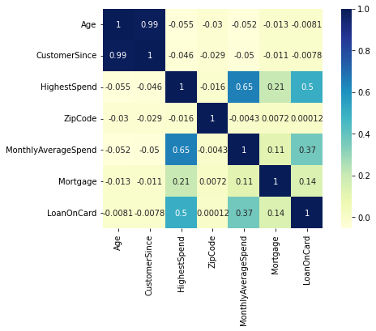

```python
corr = result.corr()
plt.figure(figsize=(8,5))
ax = sns.heatmap(corr, square=True, annot=True, cmap="YlGnBu")
```

*Age and Customer Since are hingly correlated and can affect the model accuaracy.*

**C. Check for unexpected values in each categorical variable and impute with best suitable value.**

```python
category = []
for col in result.columns:
  if result.dtypes[col] == 'object' or result.dtypes[col] == 'category':
    print(result[col].value_counts())
```

```
1    1466
2    1293
4    1215
3    1006
Name: HiddenScore, dtype: int64
1    2089
3    1496
2    1395
Name: Level, dtype: int64
0    4460
1     520
Name: Security, dtype: int64
0    4678
1     302
Name: FixedDepositAccount, dtype: int64
1    2974
0    2006
Name: InternetBanking, dtype: int64
0    3514
1    1466
Name: CreditCard, dtype: int64
```

*There are no unexpected value found*

**Explore Categorical Variables**

```python
# find categorical variables

categorical = [var for var in result.columns if result[var].dtype=='O']

print('There are {} categorical variables\n'.format(len(categorical)))

print('The categorical variables are :', categorical)
```

```
There are 6 categorical variables

The categorical variables are : ['HiddenScore', 'Level', 'Security', 'FixedDepositAccount', 'InternetBanking', 'CreditCard']
```

```python
# view the categorical variables

result[categorical].head()
```

|  | HiddenScore | Level | Security | FixedDepositAccount | InternetBanking | CreditCard |
| --- | --- | --- | --- | --- | --- | --- |
| 9 | 1 | 3 | 0 | 0 | 0 | 0 |
| 10 | 4 | 3 | 0 | 0 | 0 | 0 |
| 11 | 3 | 2 | 0 | 0 | 1 | 0 |
| 12 | 2 | 3 | 1 | 0 | 0 | 0 |
| 13 | 4 | 2 | 0 | 0 | 1 | 0 |

**Explore problems within categorical variables** </br> First, I will explore the categorical variables.

Missing values in categorical variables

```python
# check missing values in categorical variables

result[categorical].isnull().sum()
```

```
HiddenScore            0
Level                  0
Security               0
FixedDepositAccount    0
InternetBanking        0
CreditCard             0
dtype: int64
```

There are no missing values in categorical variable

```python
# print categorical variables containing missing values

cat1 = [var for var in categorical if result[var].isnull().sum()!=0]

print(result[cat1].isnull().sum())
```

```
Series([], dtype: float64)
```

**Frequency counts of categorical variables** </br> Now, I will check the frequency counts of categorical variables.

```python
# view frequency of categorical variables

for var in categorical:
    print(result[var].value_counts())
```

```
1    1466
2    1293
4    1215
3    1006
Name: HiddenScore, dtype: int64
1    2089
3    1496
2    1395
Name: Level, dtype: int64
0    4460
1     520
Name: Security, dtype: int64
0    4678
1     302
Name: FixedDepositAccount, dtype: int64
1    2974
0    2006
Name: InternetBanking, dtype: int64
0    3514
1    1466
Name: CreditCard, dtype: int64
```

```python
# view frequency distribution of categorical variables

for var in categorical:

    print(result[var].value_counts()/float(len(result)))
```

```
1    0.294378
2    0.259639
4    0.243976
3    0.202008
Name: HiddenScore, dtype: float64
1    0.419478
3    0.300402
2    0.280120
Name: Level, dtype: float64
0    0.895582
1    0.104418
Name: Security, dtype: float64
0    0.939357
1    0.060643
Name: FixedDepositAccount, dtype: float64
1    0.597189
0    0.402811
Name: InternetBanking, dtype: float64
0    0.705622
1    0.294378
Name: CreditCard, dtype: float64
```

**Number of labels: cardinality** </br> The number of labels within a categorical variable is known as cardinality. A high number of labels within a variable is known as high cardinality. High cardinality may pose some serious problems in the machine learning model. So, I will check for high cardinality.

```python
# check for cardinality in categorical variables

for var in categorical:

    print(var, ' contains ', len(result[var].unique()), ' labels')
```

```
HiddenScore  contains  4  labels
Level  contains  3  labels
Security  contains  2  labels
FixedDepositAccount  contains  2  labels
InternetBanking  contains  2  labels
CreditCard  contains  2  labels
```

There are no cardinality

**One Hot Encoding for Categorical variable**

```python
# let's do One Hot Encoding of categorical variable
# get k-1 dummy variables after One Hot Encoding
# also add an additional dummy variable to indicate there was missing data
# preview the dataset with head() method

for var in categorical:
  print(pd.get_dummies(result[var], drop_first=True, dummy_na=True).head())
  print("")
  print("*" * 30)
  print("")
```

```
    2.0  3.0  4.0  NaN
9     0    0    0    0
10    0    0    1    0
11    0    1    0    0
12    1    0    0    0
13    0    0    1    0


    2.0  3.0  NaN
9     0    1    0
10    0    1    0
11    1    0    0
12    0    1    0
13    1    0    0


    1.0  NaN
9     0    0
10    0    0
11    0    0
12    1    0
13    0    0


    1.0  NaN
9     0    0
10    0    0
11    0    0
12    0    0
13    0    0


    1.0  NaN
9     0    0
10    0    0
11    1    0
12    0    0
13    1    0


    1.0  NaN
9     0    0
10    0    0
11    0    0
12    0    0
13    0    0
```

```python
# sum the number of 1s per boolean variable over the rows of the dataset
# it will tell us how many observations we have for each category
for var in categorical:
  print(pd.get_dummies(result[var], drop_first=True, dummy_na=True).sum(axis=0))
  print("")
  print("*" * 10)
  print("")
```

```
2.0    1293
3.0    1006
4.0    1215
NaN       0
dtype: int64

**********

2.0    1395
3.0    1496
NaN       0
dtype: int64

**********

1.0    520
NaN      0
dtype: int64

**********

1.0    302
NaN      0
dtype: int64

**********

1.0    2974
NaN       0
dtype: int64

**********

1.0    1466
NaN       0
dtype: int64

**********
```

**Explore Numerical Variables**

zip codes, take numerical values, but are not quantitative: They are qualitative or categorical variables. The sum of two zip codes is not meaningful. The average of a list of zip codes is not meaningful.

And it has a high number of labels. </br> A high number of labels within a variable is known as high cardinality. High cardinality may pose some serious problems in the machine learning model.

So it make sence to remove Zipcode from data set

```python
result.ZipCode.unique()
```

```
array([93023, 94710, 90277, 93106, 94920, 91741, 95054, 95010, 94305,
       91604, 94720, 94015, 90095, 91320, 95521, 95064, 90064, 94539,
       94104, 94117, 94801, 91330, 94035, 92647, 95814, 94114, 94115,
       92672, 94122, 90019, 95616, 94065, 95014, 91380, 95747, 92373,
       92093, 94005, 90245, 95819, 94022, 90404, 93407, 90089, 94523,
       90024, 91360, 95670, 95123, 90045, 91335, 93907, 92007, 94606,
       94611, 94901, 92220, 93305, 94105, 94550, 92612, 95617, 92121,
       92374, 91711, 94080, 94608, 93555, 93311, 94704, 92717, 92037,
       95136, 94542, 94143, 91775, 92703, 92354, 92024, 92831, 92833,
       94304, 90057, 92130, 91301, 92096, 92646, 92182, 92131, 93720,
       90840, 95035, 93010, 94928, 95831, 91770, 90007, 94102, 91423,
       93955, 94107, 92834, 93117, 94551, 94596, 94025, 94545, 95053,
       90036, 91125, 95120, 94706, 95827, 90503, 90250, 95817, 95503,
       93111, 94132, 95818, 91942, 90401, 93524, 95133, 92173, 94043,
       92521, 92122, 93118, 92697, 94577, 91345, 94123, 92152, 91355,
```

[output cut: 37 more lines]

```python
result.drop('ZipCode', axis=1, inplace = True)
```

```python
# find numerical variables

numerical = [var for var in result.columns if result[var].dtype!='O']

print('There are {} numerical variables\n'.format(len(numerical)))

print('The numerical variables are :', numerical)
```

```
There are 6 numerical variables

The numerical variables are : ['Age', 'CustomerSince', 'HighestSpend', 'MonthlyAverageSpend', 'Mortgage', 'LoanOnCard']
```

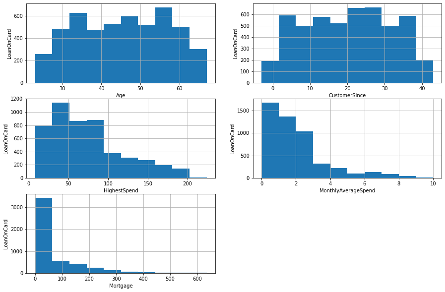

```python
# plot histogram to check distribution

plt.figure(figsize=(15,10))


plt.subplot(3, 2, 1)
fig = result.Age.hist(bins=10)
fig.set_xlabel('Age')
fig.set_ylabel('LoanOnCard')


plt.subplot(3, 2, 2)
fig = result.CustomerSince.hist(bins=10)
fig.set_xlabel('CustomerSince')
fig.set_ylabel('LoanOnCard')


plt.subplot(3, 2, 3)
fig = result.HighestSpend.hist(bins=10)
fig.set_xlabel('HighestSpend')
fig.set_ylabel('LoanOnCard')


plt.subplot(3, 2, 4)
fig = result.MonthlyAverageSpend.hist(bins=10)
fig.set_xlabel('MonthlyAverageSpend')
fig.set_ylabel('LoanOnCard')


plt.subplot(3, 2, 5)
fig = result.Mortgage.hist(bins=10)
fig.set_xlabel('Mortgage')
fig.set_ylabel('LoanOnCard')
```

We can see that three variables are skewed. So, I will use interquantile range to find outliers.

```python
# find outliers for Rainfall variable

def find_outliears(feature):
  IQR = result[feature].quantile(0.75) - result[feature].quantile(0.25)
  Lower_fence = result[feature].quantile(0.25) - (IQR * 3)
  Upper_fence = result[feature].quantile(0.75) + (IQR * 3)
  print(f'{feature} outliers are values < {Lower_fence} or > {Upper_fence}')

for var in numerical:
  find_outliears(var)
```

```
Age outliers are values < -25.0 or > 115.0
CustomerSince outliers are values < -50.0 or > 90.0
HighestSpend outliers are values < -138.0 or > 275.0
MonthlyAverageSpend outliers are values < -4.7749999999999995 or > 8.0
Mortgage outliers are values < -303.0 or > 404.0
LoanOnCard outliers are values < 0.0 or > 0.0
```

# **3. Data Preparation and model building**

**A. Split data into X and Y**

```python
X = result.drop(['LoanOnCard'], axis=1)

y = result[['LoanOnCard']]
```

```python
#Convert categorical vriables to dummy variables
X = pd.get_dummies(X, drop_first=True)
```

```python
X.head()
```

|  | Age | CustomerSince | HighestSpend | MonthlyAverageSpend | Mortgage | HiddenScore_2 | HiddenScore_3 | HiddenScore_4 | Level_2 | Level_3 | Security_1 | FixedDepositAccount_1 | InternetBanking_1 | CreditCard_1 |
| --- | --- | --- | --- | --- | --- | --- | --- | --- | --- | --- | --- | --- | --- | --- |
| 9 | 34 | 9 | 180 | 8.9 | 0 | 0 | 0 | 0 | 0 | 1 | 0 | 0 | 0 | 0 |
| 10 | 65 | 39 | 105 | 2.4 | 0 | 0 | 0 | 1 | 0 | 1 | 0 | 0 | 0 | 0 |
| 11 | 29 | 5 | 45 | 0.1 | 0 | 0 | 1 | 0 | 1 | 0 | 0 | 0 | 1 | 0 |
| 12 | 48 | 23 | 114 | 3.8 | 0 | 1 | 0 | 0 | 0 | 1 | 1 | 0 | 0 | 0 |
| 13 | 59 | 32 | 40 | 2.5 | 0 | 0 | 0 | 1 | 1 | 0 | 0 | 0 | 1 | 0 |

**B. Split data into train and test. Keep 25% data reserved for testing**

```python
# split X and y into training and testing sets
X_train, X_test, y_train, y_test = train_test_split(X, y, test_size = 0.25, random_state = 0)
```

```python
# check the shape of X_train and X_test

X_train.shape, X_test.shape
```

```
((3735, 14), (1245, 14))
```

```python
# check the shape of X_train and X_test

y_train.shape, y_test.shape
```

```
((3735, 1), (1245, 1))
```

**C. Train a Supervised Learning Classification base model - Logistic Regression.**

```python
from sklearn.linear_model import LogisticRegression
```

```python
#Build the logistic regression model
logreg = LogisticRegression(max_iter=1000)
```

```python
logreg.fit(X_train, y_train.values.ravel())
```

```
LogisticRegression(max_iter=1000)
```

**Prediction**

```python
#Predict for test set
pred_test = logreg.predict(X_test)
```

```python
pred_test
```

```
array([0., 0., 0., ..., 1., 0., 0.])
```

```python
#Predict for train set
pred_train = logreg.predict(X_train)
```

```python
from sklearn.metrics import accuracy_score
test_accuracy=accuracy_score(y_test, pred_test)

print('Test Accuracy: ', round(test_accuracy,3))
```

```
Test Accuracy:  0.963
```

```python
train_accuracy=accuracy_score(y_train, pred_train)

print('Train Accuracy: ', round(train_accuracy,3))
```

```
Train Accuracy:  0.958
```

```python
test_recall = round(recall_score(y_train, pred_train), 3)
print("test recall score", test_recall)
```

```
test recall score 0.668
```

```python
test_f1_score = round(f1_score(y_train, pred_train), 3)
print("test f1 score", test_f1_score)
```

```
test f1 score 0.758
```

**D. Print evaluation metrics for the model and clearly share insights.**

**Confusion matrix**

```python
from sklearn.metrics import classification_report,confusion_matrix
mat_train = confusion_matrix(y_train,pred_train)

print("confusion matrix_train_data = \n",mat_train)
```

```
confusion matrix_train_data =
 [[3330   35]
 [ 123  247]]
```

```python
mat_test = confusion_matrix(y_test,pred_test)
print("confusion matrix_test_data = \n",mat_test)
```

```
confusion matrix_test_data =
 [[1121   14]
 [  32   78]]
```

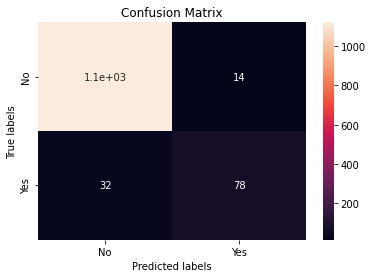

```python
import seaborn as sns
import matplotlib.pyplot as plt

ax= plt.subplot()
sns.heatmap(mat_test, annot=True, ax = ax); #annot=True to annotate cells

# labels, title and ticks
ax.set_xlabel('Predicted labels');ax.set_ylabel('True labels');
ax.set_title('Confusion Matrix');
ax.xaxis.set_ticklabels(['No', 'Yes']); ax.yaxis.set_ticklabels(['No', 'Yes']);
```

**ROC Curve**

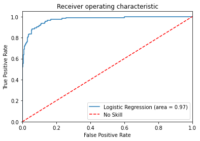

```python
#AUC ROC curve
from sklearn.metrics import roc_auc_score
from sklearn.metrics import roc_curve

logit_roc_auc = roc_auc_score(y_test, logreg.predict_proba(X_test)[:,1])
fpr, tpr, thresholds = roc_curve(y_test, logreg.predict_proba(X_test)[:,1])
plt.figure()
plt.plot(fpr, tpr, label='Logistic Regression (area = %0.2f)' % logit_roc_auc)
plt.plot([0, 1], [0, 1],'r--',label='No Skill')
plt.xlim([0.0, 1.0])
plt.ylim([0.0, 1.05])
plt.xlabel('False Positive Rate')
plt.ylabel('True Positive Rate')
plt.title('Receiver operating characteristic')
plt.legend(loc="lower right")
plt.savefig('Log_ROC')
plt.show()
```

```
Best Threshold=0.096766, G-Mean=0.913
```

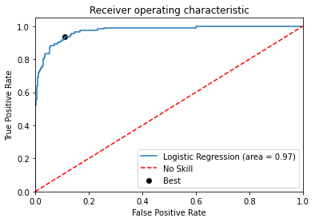

```python
#AUC ROC curve
from sklearn.metrics import roc_auc_score
from sklearn.metrics import roc_curve
# roc curve for logistic regression model with optimal threshold
from numpy import sqrt
from numpy import argmax

logit_roc_auc = roc_auc_score(y_test, logreg.predict_proba(X_test)[:,1])
fpr, tpr, thresholds = roc_curve(y_test, logreg.predict_proba(X_test)[:,1])
# calculate the g-mean for each threshold
gmeans = sqrt(tpr * (1-fpr))
# locate the index of the largest g-mean
ix = argmax(gmeans)
print('Best Threshold=%f, G-Mean=%.3f' % (thresholds[ix], gmeans[ix]))
plt.figure()
plt.plot(fpr, tpr, label='Logistic Regression (area = %0.2f)' % logit_roc_auc)
plt.plot([0, 1], [0, 1],'r--',label='No Skill')
plt.scatter(fpr[ix], tpr[ix], marker='o', color='black', label='Best')
plt.xlim([0.0, 1.0])
plt.ylim([0.0, 1.05])
plt.xlabel('False Positive Rate')
plt.ylabel('True Positive Rate')
plt.title('Receiver operating characteristic')
plt.legend(loc="lower right")
plt.savefig('Log_ROC')
plt.show()
```

**Precission recall curve**

```
Best Threshold=0.476288, F-Score=0.777
```

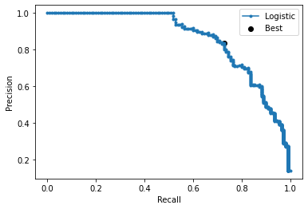

```python
from sklearn.metrics import precision_recall_curve
yhat=logreg.predict_proba(X_test)[:,1]
# calculate roc curves
precision, recall, thresholds = precision_recall_curve(y_test, yhat)
# convert to f score
fscore = (2 * precision * recall) / (precision + recall)
# locate the index of the largest f score
ix = argmax(fscore)
print('Best Threshold=%f, F-Score=%.3f' % (thresholds[ix], fscore[ix]))
plt.plot(recall, precision, marker='.', label='Logistic')
plt.scatter(recall[ix], precision[ix], marker='o', color='black', label='Best')
# axis labels
plt.xlabel('Recall')
plt.ylabel('Precision')
plt.legend()
# show the plot
plt.show()
```

**E. Balance the data using the right balancing technique**

i. Check distribution of the target variable

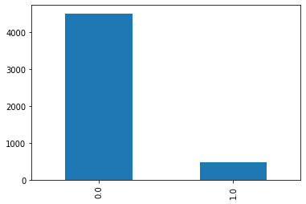

```python
result['LoanOnCard'].value_counts().plot(kind='bar')
```

```python
output = result['LoanOnCard'].value_counts(normalize=True)

print(f" output is class A : {round(output[0] * 100, 2)}% and class B : {round(output[1] * 100, 2)}%")
```

```
 output is class A : 90.36% and class B : 9.64%
```

```python
# class count
class_count_0, class_count_1 = result['LoanOnCard'].value_counts()

# Separate class
class_0 = result[result['LoanOnCard'] == 0]
class_1 = result[result['LoanOnCard'] == 1]# print the shape of the class
print('class 0:', class_0.shape)
print('class 1:', class_1.shape)
```

```
class 0: (4500, 12)
class 1: (480, 12)
```

**Random Under-Sampling**

```
Original LoanOnCard
0.0           3365
1.0            370
dtype: int64
RUS LoanOnCard
0.0           370
1.0           370
dtype: int64
```

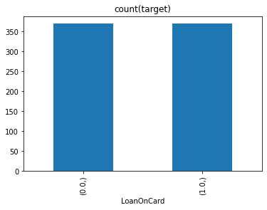

```python
# import library
from imblearn.under_sampling import RandomUnderSampler
from collections import Counter
rus = RandomUnderSampler()
x_rus, y_rus = rus.fit_resample(X_train, y_train)

print("Original", y_train.value_counts())
print("RUS", y_rus.value_counts())

y_rus.value_counts().plot(kind='bar', title='count(target)')
```

**F. Again train the same previous model on balanced data.**

```python
#Build the logistic regression model
logreg_rus = LogisticRegression(max_iter=10000)
```

```python
logreg_rus.fit(x_rus, y_rus.values.ravel())
```

```
LogisticRegression(max_iter=10000)
```

**Prediction**

```python
#Predict for test set
y_pred = logreg.predict(X_test)
```

```python
# Checking accuracy
rus_accuracy = round(accuracy_score(y_test, y_pred), 3)
print("Test accuracy after applying randaom under samplling", rus_accuracy)
```

```
Test accuracy after applying randaom under samplling 0.963
```

```python
# f1 score
rus_f1_score = round(f1_score(y_test, y_pred), 3)
print("F1 Score after appyinh random under samplling", rus_f1_score)
```

```
F1 Score after appyinh random under samplling 0.772
```

```python
mat_test_rus = confusion_matrix(y_test,pred_test)
print("confusion matrix_test_data = \n", mat_test_rus)
```

```
confusion matrix_test_data =
 [[1121   14]
 [  32   78]]
```

```python
# confusion matrix
pd.DataFrame(confusion_matrix(y_test, y_pred))
```

|  | 0 | 1 |
| --- | --- | --- |
| 0 | 1121 | 14 |
| 1 | 32 | 78 |

```python
rus_recall = recall_score(y_test, y_pred)
print("Recall score after random under sampling", rus_recall)
```

```
Recall score after random under sampling 0.7090909090909091
```

```python
print(f"Model Accuracy in imbalanced data {round(test_accuracy, 3)}")
print(f"Model Accuracy in Random balanced data {rus_accuracy}")

print(f" Accuracy differecne in Imbalanced data vs balanced data -  {round(test_accuracy, 3) - rus_accuracy}")
```

```
Model Accuracy in imbalanced data 0.963
Model Accuracy in Random balanced data 0.963
 Accuracy differecne in Imbalanced data vs balanced data -  0.0
```

```python
print(f"Model f1 score in imbalanced data {test_f1_score}")
print(f"Model f1 score in Random balanced data {rus_f1_score}")

print(f" f1 score differecne in Imbalanced data vs balanced data -  {rus_f1_score - test_f1_score}")
```

```
Model f1 score in imbalanced data 0.758
Model f1 score in Random balanced data 0.772
 f1 score differecne in Imbalanced data vs balanced data -  0.014000000000000012
```

```python
print(f"Model recall in imbalanced data {test_recall}")
print(f"Model recall in Random balanced data {rus_recall}")

print(f" Recall differecne in Imbalanced data vs balanced data -  {rus_recall - test_recall}")
```

```
Model recall in imbalanced data 0.668
Model recall in Random balanced data 0.7090909090909091
 Recall differecne in Imbalanced data vs balanced data -  0.04109090909090907
```

**SMOT Technique**

```python
# transform the dataset
from imblearn.over_sampling import SMOTE
oversample = SMOTE()
X_smote, y_smote = oversample.fit_resample(X_train, y_train)
```

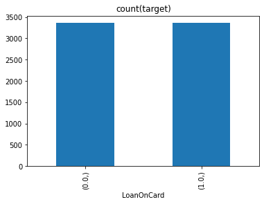

```python
y_smote.value_counts().plot(kind='bar', title='count(target)')
```

```python
#Build the logistic regression model
logreg_smote = LogisticRegression(max_iter=10000)
```

```python
logreg_smote.fit(X_smote, y_smote.values.ravel())
```

```
LogisticRegression(max_iter=10000)
```

```python
#Predict for test set
y_pred_smote = logreg_smote.predict(X_test)
```

```python
# Checking accuracy
smote_accuracy = round(accuracy_score(y_test, y_pred_smote), 3)
print("Test accuracy after applying SMOTE", smote_accuracy)
```

```
Test accuracy after applying SMOTE 0.892
```

```python
# f1 score
smote_f1_score = round(f1_score(y_test, y_pred_smote), 3)
print("F1 Score after appying SMOTE", smote_f1_score)
```

```
F1 Score after appying SMOTE 0.59
```

```python
smote_recall = recall_score(y_test, y_pred_smote)
print("Recall score after SMOTE", smote_recall)
```

```
Recall score after SMOTE 0.8818181818181818
```

We can infer that there is drastic change in Accuaracy, recall and f1_score after applying SMOTE data balancing techning.

**4. Performance Improvement**

**A. Train a base model each for SVM, KNN.**

*SVM*

```python
#Import svm model
from sklearn import svm

#Create a svm Classifier
clf = svm.SVC()

#Train the model using the training sets
clf.fit(X_train, y_train.values.ravel())

#Predict the response for test dataset
y_pred_svm = clf.predict(X_test)
```

```python
# print classification report
print(classification_report(y_test, y_pred_svm))

# New Model Evaluation metrics
print('Accuracy Score : ' + str(accuracy_score(y_test,y_pred_svm)))
print('Precision Score : ' + str(precision_score(y_test,y_pred_svm)))
print('Recall Score : ' + str(recall_score(y_test,y_pred_svm)))
print('F1 Score : ' + str(f1_score(y_test,y_pred_svm)))

#Logistic Regression (Grid Search) Confusion matrix
confusion_matrix(y_test,y_pred_svm)
```

```
              precision    recall  f1-score   support

         0.0       0.92      0.99      0.96      1135
         1.0       0.60      0.11      0.18       110

    accuracy                           0.91      1245
   macro avg       0.76      0.55      0.57      1245
weighted avg       0.89      0.91      0.89      1245

Accuracy Score : 0.914859437751004
Precision Score : 0.6
Recall Score : 0.10909090909090909
F1 Score : 0.1846153846153846
```

```
array([[1127,    8],
       [  98,   12]])
```

```python
#Grid Search
from sklearn.model_selection import GridSearchCV


# defining parameter range
param_grid = {'C': [0.1, 1, 10, 100, 1000],
              'gamma': [1, 0.1, 0.01, 0.001, 0.0001],
              'kernel': ['rbf']}

grid = GridSearchCV(svm.SVC(), param_grid, refit = True, verbose = 3)

# fitting the model for grid search
grid.fit(X_train, y_train.values.ravel())

# print best parameter after tuning
print(grid.best_params_)

# print how our model looks after hyper-parameter tuning
print(grid.best_estimator_)

grid_predictions = grid.predict(X_test)

# print classification report
print(classification_report(y_test, grid_predictions))

# New Model Evaluation metrics
print('Accuracy Score : ' + str(accuracy_score(y_test,grid_predictions)))
print('Precision Score : ' + str(precision_score(y_test,grid_predictions)))
print('Recall Score : ' + str(recall_score(y_test,grid_predictions)))
print('F1 Score : ' + str(f1_score(y_test,grid_predictions)))

#Logistic Regression (Grid Search) Confusion matrix
confusion_matrix(y_test,grid_predictions)
```

[output not shown]

[output cut: 86 more lines]

```
{'C': 1000, 'gamma': 0.0001, 'kernel': 'rbf'}
SVC(C=1000, gamma=0.0001)
              precision    recall  f1-score   support

         0.0       0.98      0.99      0.98      1135
         1.0       0.89      0.76      0.82       110

    accuracy                           0.97      1245
   macro avg       0.94      0.88      0.90      1245
weighted avg       0.97      0.97      0.97      1245

Accuracy Score : 0.9710843373493976
Precision Score : 0.8936170212765957
Recall Score : 0.7636363636363637
F1 Score : 0.8235294117647058
```

```
array([[1125,   10],
       [  26,   84]])
```

- Final model is 6% more accurate than base model
- Final model is having more precision score hence more precise
- Final model has drastic change in recall value

*KNN*

```python
from sklearn.neighbors import KNeighborsClassifier

knn_model = KNeighborsClassifier(n_neighbors=3)

# Train the model using the training sets
knn_model.fit(X_train, y_train.values.ravel())

#Predict Output
y_pred_knn= knn_model.predict(X_test)
```

```python
# print classification report
print(classification_report(y_test, y_pred_knn))

# New Model Evaluation metrics
print('Accuracy Score : ' + str(accuracy_score(y_test,y_pred_knn)))
print('Precision Score : ' + str(precision_score(y_test,y_pred_knn)))
print('Recall Score : ' + str(recall_score(y_test,y_pred_knn)))
print('F1 Score : ' + str(f1_score(y_test,y_pred_knn)))

#Logistic Regression (Grid Search) Confusion matrix
confusion_matrix(y_test,y_pred_knn)
```

```
              precision    recall  f1-score   support

         0.0       0.95      0.96      0.95      1135
         1.0       0.48      0.44      0.46       110

    accuracy                           0.91      1245
   macro avg       0.72      0.70      0.70      1245
weighted avg       0.91      0.91      0.91      1245

Accuracy Score : 0.9092369477911647
Precision Score : 0.48484848484848486
Recall Score : 0.43636363636363634
F1 Score : 0.45933014354066987
```

```
array([[1084,   51],
       [  62,   48]])
```

```python
knn = KNeighborsClassifier()
k_range = list(range(1, 31))
param_grid = dict(n_neighbors=k_range)

# defining parameter range
grid = GridSearchCV(knn, param_grid, cv=10, scoring='accuracy', return_train_score=False,verbose=1)

# fitting the model for grid search
grid_search=grid.fit(X_train, y_train.values.ravel())

print(grid_search.best_params_)

# print how our model looks after hyper-parameter tuning
print(grid_search.best_estimator_)
```

```
Fitting 10 folds for each of 30 candidates, totalling 300 fits
{'n_neighbors': 27}
KNeighborsClassifier(n_neighbors=27)
```

```python
knn = KNeighborsClassifier(n_neighbors=27)

knn.fit(X_train, y_train.values.ravel())


grid_predictions = grid_search.predict(X_test)

# print classification report
print(classification_report(y_test, grid_predictions))

# New Model Evaluation metrics
print('Accuracy Score : ' + str(accuracy_score(y_test,grid_predictions)))
print('Precision Score : ' + str(precision_score(y_test,grid_predictions)))
print('Recall Score : ' + str(recall_score(y_test,grid_predictions)))
print('F1 Score : ' + str(f1_score(y_test,grid_predictions)))

#Logistic Regression (Grid Search) Confusion matrix
confusion_matrix(y_test,grid_predictions)
```

```
              precision    recall  f1-score   support

         0.0       0.94      0.97      0.95      1135
         1.0       0.49      0.31      0.38       110

    accuracy                           0.91      1245
   macro avg       0.71      0.64      0.66      1245
weighted avg       0.90      0.91      0.90      1245

Accuracy Score : 0.9100401606425703
Precision Score : 0.4857142857142857
Recall Score : 0.3090909090909091
F1 Score : 0.3777777777777777
```

```
array([[1099,   36],
       [  76,   34]])
```

- Final model has a little improvement than base model in terms of accuracy
- Final model is almost same in terms of precision score
- final model has lesser recall value